# Non-Navigation Cognitive/Behavioral Analysis: Low NARA Scorers (BNC01 & BNC037)

Analysis

2025-11-12

## Introduction

This analysis examines the cognitive and behavioral test performance of two young adult participants (BNC01 and BNC037) who scored below the NARA cutoff of 3.5, comparing them to the rest of the young adult cohort.

```r
library(tidyverse)
library(ggplot2)
library(knitr)
library(patchwork)
```

```r
# Load the data
non_nav <- read.csv("/Volumes/YB_Drive/NavAging_Paper/data/non_nav_data.csv")

# Filter to YA group only
ya_non_nav <- non_nav %>%
  filter(Group == "YA")

# Identify low NARA scorers
low_nara <- c("BNC01", "BNC37")

# Add grouping variable
ya_non_nav <- ya_non_nav %>%
  mutate(NARA_Group = case_when(
    Participant %in% low_nara ~ "Low NARA (< 3.5)",
    TRUE ~ "Normal NARA"
  ))

# Show basic info
cat("Total YA participants:", nrow(ya_non_nav), "\n")
```

```
## Total YA participants: 30
```

```r
cat("Low NARA participants:", sum(ya_non_nav$Participant %in% low_nara), "\n")
```

```
## Low NARA participants: 2
```

```r
cat("Normal NARA participants:", sum(!ya_non_nav$Participant %in% low_nara), "\n\n")
```

```
## Normal NARA participants: 28
```

## Data Preparation

```r
# Select key measures of interest
# Note: Some columns are stored as strings and need conversion

# Convert string columns to numeric where appropriate
ya_non_nav_clean <- ya_non_nav %>%
  mutate(
    NBWT_ON_Mean = as.numeric(NBWT_ON_Mean),
    # Calculate Trails B - A
    Trails_BA_Diff = Trails_B_CT - Trails_A_CT
  )

# Select measures of interest for analysis
measures_of_interest <- ya_non_nav_clean %>%
  select(
    Participant, NARA_Group, Group, NARA,
    # Sleep and subjective measures
    PSQI, SSS_Pre, SSS_Post, SSQ_Pre, SSQ_Post, SSQ_Diff,
    # Cognitive measures
    SBSOD, MiniCog,
    Trails_A_CT, Trails_A_Dwell, Trails_B_CT, Trails_B_Dwell,
    Trails_BA_Diff, SetShifting,
    Corsi_Score_Total, Corsi_Score_Mean, Corsi_Span
  ) %>%
  ungroup()

# Show summary
cat("Measures included in analysis:\n")
```

```
## Measures included in analysis:
```

```r
cat(paste(setdiff(colnames(measures_of_interest), c("Participant", "NARA_Group")),
          collapse = ", "), "\n\n")
```

```
## Group, NARA, PSQI, SSS_Pre, SSS_Post, SSQ_Pre, SSQ_Post, SSQ_Diff, SBSOD, MiniCog, Trails_A_CT, Trails_A_Dwell, Trails_B_CT, Trails_B_Dwell, Trails_BA_Diff, SetShifting, Corsi_Score_Total, Corsi_Score_Mean, Corsi_Span
```

```r
# Show data for low NARA participants
kable(measures_of_interest %>%
        filter(Participant %in% low_nara) %>%
        arrange(NARA),
      caption = "All Measures for BNC01 and BNC037", digits = 2)
```

All Measures for BNC01 and BNC037

| Participant | NARA_Group | Group | NARA | PSQI | SSS_Pre | SSS_Post | SSQ_Pre | SSQ_Post | SSQ_Diff | SBSOD | MiniCog | Trails_A_CT | Trails_A_Dwell | Trails_B_CT | Trails_B_Dwell | Trails_BA_Diff | SetShifting | Corsi_Score_Total | Corsi_Score_Mean | Corsi_Span |
| --- | --- | --- | --- | --- | --- | --- | --- | --- | --- | --- | --- | --- | --- | --- | --- | --- | --- | --- | --- | --- |
| BNC37 | Low NARA (< 3.5) | YA | 1.5 | 12 | 1 | 1 | 3 | 6 | 3 | 4.87 | 5 | 25.0 | 8.0 | 52.2 | 19.2 | 27.2 | 27.2 | 79 | 4.9 | 7 |
| BNC01 | Low NARA (< 3.5) | YA | 3.0 | 5 | 2 | 4 | 4 | 10 | 6 | 2.20 | 5 | 30.3 | 9.8 | 27.8 | 10.7 | -2.5 | -2.5 | 74 | 4.6 | 6 |

## Summary Statistics

```r
# Calculate summary statistics by NARA group
numeric_cols <- measures_of_interest %>%
  select(where(is.numeric), -Group, -NARA) %>%
  colnames()

summary_stats <- measures_of_interest %>%
  group_by(NARA_Group) %>%
  summarise(
    N = n(),
    across(all_of(numeric_cols),
           list(Mean = ~mean(., na.rm = TRUE),
                SD = ~sd(., na.rm = TRUE)),
           .names = "{.col}_{.fn}")
  ) %>%
  ungroup()

# Reshape for better display
summary_long <- summary_stats %>%
  pivot_longer(-c(NARA_Group, N),
               names_to = "Metric",
               values_to = "Value") %>%
  separate(Metric, into = c("Measure", "Stat"), sep = "_(?=[^_]*$)") %>%
  pivot_wider(names_from = Stat, values_from = Value) %>%
  arrange(Measure)

kable(summary_long, digits = 2,
      caption = "Summary Statistics: Low NARA vs Normal NARA Young Adults")
```

Summary Statistics: Low NARA vs Normal NARA Young Adults

| NARA_Group | N | Measure | Mean | SD |
| --- | --- | --- | --- | --- |
| Low NARA (< 3.5) | 2 | Corsi_Score_Mean | 4.75 | 0.21 |
| Normal NARA | 28 | Corsi_Score_Mean | 5.64 | 0.64 |
| Low NARA (< 3.5) | 2 | Corsi_Score_Total | 76.50 | 3.54 |
| Normal NARA | 28 | Corsi_Score_Total | 90.11 | 10.18 |
| Low NARA (< 3.5) | 2 | Corsi_Span | 6.50 | 0.71 |
| Normal NARA | 28 | Corsi_Span | 6.68 | 0.77 |
| Low NARA (< 3.5) | 2 | MiniCog | 5.00 | 0.00 |
| Normal NARA | 28 | MiniCog | 4.79 | 0.50 |
| Low NARA (< 3.5) | 2 | PSQI | 8.50 | 4.95 |
| Normal NARA | 28 | PSQI | 4.86 | 1.51 |
| Low NARA (< 3.5) | 2 | SBSOD | 3.54 | 1.89 |
| Normal NARA | 28 | SBSOD | 4.41 | 1.06 |
| Low NARA (< 3.5) | 2 | SSQ_Diff | 4.50 | 2.12 |
| Normal NARA | 28 | SSQ_Diff | 0.75 | 3.26 |
| Low NARA (< 3.5) | 2 | SSQ_Post | 8.00 | 2.83 |
| Normal NARA | 28 | SSQ_Post | 3.21 | 4.05 |
| Low NARA (< 3.5) | 2 | SSQ_Pre | 3.50 | 0.71 |
| Normal NARA | 28 | SSQ_Pre | 2.46 | 2.33 |
| Low NARA (< 3.5) | 2 | SSS_Post | 2.50 | 2.12 |
| Normal NARA | 28 | SSS_Post | 1.79 | 1.07 |
| Low NARA (< 3.5) | 2 | SSS_Pre | 1.50 | 0.71 |
| Normal NARA | 28 | SSS_Pre | 2.04 | 1.07 |
| Low NARA (< 3.5) | 2 | SetShifting | 12.35 | 21.00 |
| Normal NARA | 28 | SetShifting | 10.87 | 9.32 |
| Low NARA (< 3.5) | 2 | Trails_A_CT | 27.65 | 3.75 |
| Normal NARA | 28 | Trails_A_CT | 25.79 | 4.64 |
| Low NARA (< 3.5) | 2 | Trails_A_Dwell | 8.90 | 1.27 |
| Normal NARA | 28 | Trails_A_Dwell | 10.93 | 2.93 |
| Low NARA (< 3.5) | 2 | Trails_BA_Diff | 12.35 | 21.00 |
| Normal NARA | 28 | Trails_BA_Diff | 10.87 | 9.32 |
| Low NARA (< 3.5) | 2 | Trails_B_CT | 40.00 | 17.25 |
| Normal NARA | 28 | Trails_B_CT | 36.66 | 11.00 |
| Low NARA (< 3.5) | 2 | Trails_B_Dwell | 14.95 | 6.01 |
| Normal NARA | 28 | Trails_B_Dwell | 18.37 | 6.58 |

## Distribution Comparisons

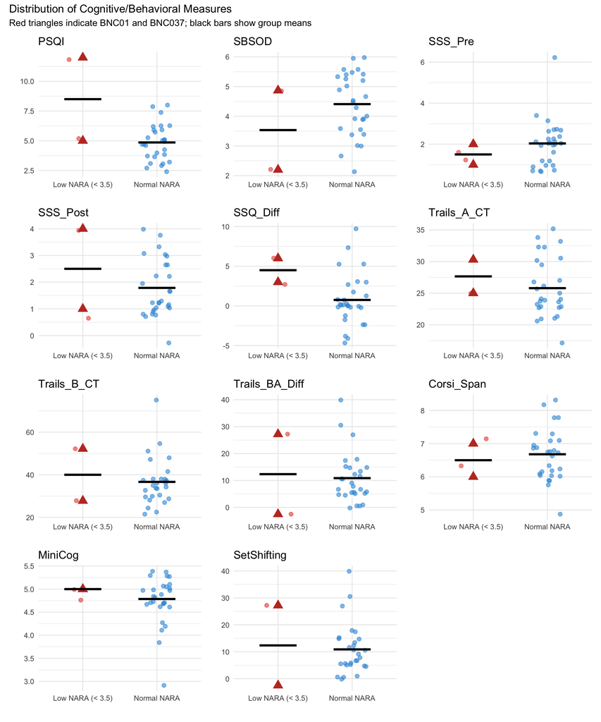

```r
# Create color palette
colors <- c("Low NARA (< 3.5)" = "#e74c3c", "Normal NARA" = "#3498db")

# Select key measures to visualize
key_measures <- c("PSQI", "SBSOD", "SSS_Pre", "SSS_Post", "SSQ_Diff",
                  "Trails_A_CT", "Trails_B_CT", "Trails_BA_Diff",
                  "Corsi_Span", "MiniCog", "SetShifting")

# Create plots
plot_list <- list()

for (measure in key_measures) {
  p <- ggplot(measures_of_interest,
              aes(x = NARA_Group, y = .data[[measure]], color = NARA_Group)) +
    geom_jitter(width = 0.2, size = 2, alpha = 0.6) +
    geom_point(data = measures_of_interest %>% filter(Participant %in% low_nara),
               aes(x = NARA_Group, y = .data[[measure]]),
               color = "#c0392b", size = 4, shape = 17) +
    stat_summary(fun = mean, geom = "crossbar", width = 0.5, color = "black") +
    scale_color_manual(values = colors) +
    labs(title = measure, x = "", y = "") +
    theme_minimal() +
    theme(legend.position = "none")

  plot_list[[measure]] <- p
}

# Arrange plots
wrap_plots(plot_list, ncol = 3) +
  plot_annotation(
    title = "Distribution of Cognitive/Behavioral Measures",
    subtitle = "Red triangles indicate BNC01 and BNC037; black bars show group means"
  )
```

## Correlation with NARA Scores

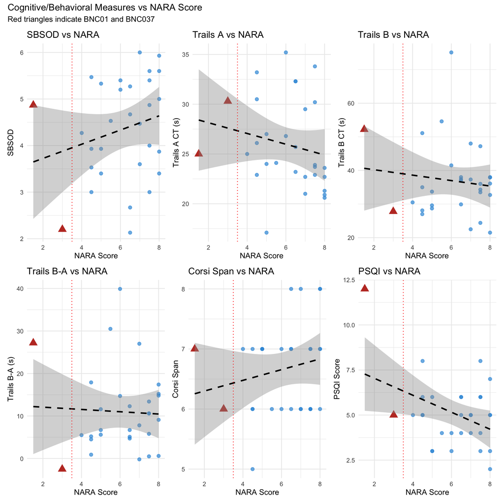

```r
# Create correlation plots for key measures
c1 <- ggplot(measures_of_interest, aes(x = NARA, y = SBSOD)) +
  geom_point(aes(color = NARA_Group), size = 2, alpha = 0.7) +
  geom_point(data = measures_of_interest %>% filter(Participant %in% low_nara),
             size = 4, color = "#c0392b", shape = 17) +
  geom_smooth(method = "lm", se = TRUE, color = "black", linetype = "dashed") +
  geom_vline(xintercept = 3.5, color = "red", linetype = "dotted") +
  scale_color_manual(values = colors) +
  labs(title = "SBSOD vs NARA", x = "NARA Score", y = "SBSOD") +
  theme_minimal() +
  theme(legend.position = "none")

c2 <- ggplot(measures_of_interest, aes(x = NARA, y = Trails_A_CT)) +
  geom_point(aes(color = NARA_Group), size = 2, alpha = 0.7) +
  geom_point(data = measures_of_interest %>% filter(Participant %in% low_nara),
             size = 4, color = "#c0392b", shape = 17) +
  geom_smooth(method = "lm", se = TRUE, color = "black", linetype = "dashed") +
  geom_vline(xintercept = 3.5, color = "red", linetype = "dotted") +
  scale_color_manual(values = colors) +
  labs(title = "Trails A vs NARA", x = "NARA Score", y = "Trails A CT (s)") +
  theme_minimal() +
  theme(legend.position = "none")

c3 <- ggplot(measures_of_interest, aes(x = NARA, y = Trails_B_CT)) +
  geom_point(aes(color = NARA_Group), size = 2, alpha = 0.7) +
  geom_point(data = measures_of_interest %>% filter(Participant %in% low_nara),
             size = 4, color = "#c0392b", shape = 17) +
  geom_smooth(method = "lm", se = TRUE, color = "black", linetype = "dashed") +
  geom_vline(xintercept = 3.5, color = "red", linetype = "dotted") +
  scale_color_manual(values = colors) +
  labs(title = "Trails B vs NARA", x = "NARA Score", y = "Trails B CT (s)") +
  theme_minimal() +
  theme(legend.position = "none")

c4 <- ggplot(measures_of_interest, aes(x = NARA, y = Trails_BA_Diff)) +
  geom_point(aes(color = NARA_Group), size = 2, alpha = 0.7) +
  geom_point(data = measures_of_interest %>% filter(Participant %in% low_nara),
             size = 4, color = "#c0392b", shape = 17) +
  geom_smooth(method = "lm", se = TRUE, color = "black", linetype = "dashed") +
  geom_vline(xintercept = 3.5, color = "red", linetype = "dotted") +
  scale_color_manual(values = colors) +
  labs(title = "Trails B-A vs NARA", x = "NARA Score", y = "Trails B-A (s)") +
  theme_minimal() +
  theme(legend.position = "none")

c5 <- ggplot(measures_of_interest, aes(x = NARA, y = Corsi_Span)) +
  geom_point(aes(color = NARA_Group), size = 2, alpha = 0.7) +
  geom_point(data = measures_of_interest %>% filter(Participant %in% low_nara),
             size = 4, color = "#c0392b", shape = 17) +
  geom_smooth(method = "lm", se = TRUE, color = "black", linetype = "dashed") +
  geom_vline(xintercept = 3.5, color = "red", linetype = "dotted") +
  scale_color_manual(values = colors) +
  labs(title = "Corsi Span vs NARA", x = "NARA Score", y = "Corsi Span") +
  theme_minimal() +
  theme(legend.position = "none")

c6 <- ggplot(measures_of_interest, aes(x = NARA, y = PSQI)) +
  geom_point(aes(color = NARA_Group), size = 2, alpha = 0.7) +
  geom_point(data = measures_of_interest %>% filter(Participant %in% low_nara),
             size = 4, color = "#c0392b", shape = 17) +
  geom_smooth(method = "lm", se = TRUE, color = "black", linetype = "dashed") +
  geom_vline(xintercept = 3.5, color = "red", linetype = "dotted") +
  scale_color_manual(values = colors) +
  labs(title = "PSQI vs NARA", x = "NARA Score", y = "PSQI Score") +
  theme_minimal() +
  theme(legend.position = "none")

(c1 + c2 + c3) / (c4 + c5 + c6) +
  plot_annotation(
    title = "Cognitive/Behavioral Measures vs NARA Score",
    subtitle = "Red triangles indicate BNC01 and BNC037"
  )
```

```r
# Calculate correlations for all numeric measures
cor_results <- data.frame()

for (measure in numeric_cols) {
  if (measure %in% colnames(measures_of_interest)) {
    test_data <- measures_of_interest %>%
      select(NARA, !!measure) %>%
      na.omit()

    if (nrow(test_data) > 2 && sd(test_data[[measure]]) > 0) {
      cor_test <- cor.test(test_data$NARA, test_data[[measure]])

      cor_results <- rbind(cor_results, data.frame(
        Measure = measure,
        Correlation = cor_test$estimate,
        P_Value = cor_test$p.value,
        N = nrow(test_data)
      ))
    }
  }
}

cor_results <- cor_results %>%
  arrange(P_Value)

kable(cor_results, digits = 3,
      caption = "Correlations between NARA Score and Cognitive/Behavioral Measures")
```

Correlations between NARA Score and Cognitive/Behavioral Measures

|  | Measure | Correlation | P_Value | N |
| --- | --- | --- | --- | --- |
| cor | PSQI | -0.401 | 0.028 | 30 |
| cor15 | Corsi_Score_Mean | 0.401 | 0.028 | 30 |
| cor14 | Corsi_Score_Total | 0.401 | 0.028 | 30 |
| cor4 | SSQ_Post | -0.288 | 0.123 | 30 |
| cor5 | SSQ_Diff | -0.250 | 0.182 | 30 |
| cor2 | SSS_Post | -0.249 | 0.185 | 30 |
| cor6 | SBSOD | 0.230 | 0.221 | 30 |
| cor8 | Trails_A_CT | -0.197 | 0.296 | 30 |
| cor16 | Corsi_Span | 0.196 | 0.300 | 30 |
| cor3 | SSQ_Pre | -0.158 | 0.403 | 30 |
| cor10 | Trails_B_CT | -0.121 | 0.523 | 30 |
| cor7 | MiniCog | 0.073 | 0.703 | 30 |
| cor1 | SSS_Pre | 0.059 | 0.756 | 30 |
| cor11 | Trails_B_Dwell | -0.055 | 0.774 | 30 |
| cor12 | Trails_BA_Diff | -0.046 | 0.810 | 30 |
| cor13 | SetShifting | -0.046 | 0.810 | 30 |
| cor9 | Trails_A_Dwell | -0.023 | 0.906 | 30 |

## Outlier Detection

### Method 1: IQR Method (Tukey’s Fences)

```r
# Function to detect outliers using IQR method
detect_iqr_outliers <- function(x) {
  q1 <- quantile(x, 0.25, na.rm = TRUE)
  q3 <- quantile(x, 0.75, na.rm = TRUE)
  iqr <- q3 - q1
  lower_fence <- q1 - 1.5 * iqr
  upper_fence <- q3 + 1.5 * iqr
  x < lower_fence | x > upper_fence
}

# Detect outliers for each metric
iqr_outliers <- measures_of_interest %>%
  select(Participant, NARA_Group, all_of(numeric_cols)) %>%
  pivot_longer(cols = all_of(numeric_cols),
               names_to = "Metric",
               values_to = "Value") %>%
  group_by(Metric) %>%
  mutate(
    Q1 = quantile(Value, 0.25, na.rm = TRUE),
    Q3 = quantile(Value, 0.75, na.rm = TRUE),
    IQR = Q3 - Q1,
    Lower_Fence = Q1 - 1.5 * IQR,
    Upper_Fence = Q3 + 1.5 * IQR,
    Is_Outlier = Value < Lower_Fence | Value > Upper_Fence,
    Outlier_Type = case_when(
      Value < Lower_Fence ~ "Low",
      Value > Upper_Fence ~ "High",
      TRUE ~ "Normal"
    )
  ) %>%
  ungroup()

# Summary of outliers for BNC01 and BNC037
low_nara_iqr <- iqr_outliers %>%
  filter(Participant %in% low_nara, !is.na(Value)) %>%
  select(Participant, Metric, Value, Q1, Q3, Lower_Fence, Upper_Fence,
         Is_Outlier, Outlier_Type)

kable(low_nara_iqr, digits = 2,
      caption = "IQR-Based Outlier Detection for BNC01 and BNC037")
```

IQR-Based Outlier Detection for BNC01 and BNC037

| Participant | Metric | Value | Q1 | Q3 | Lower_Fence | Upper_Fence | Is_Outlier | Outlier_Type |
| --- | --- | --- | --- | --- | --- | --- | --- | --- |
| BNC01 | PSQI | 5.00 | 4.00 | 6.00 | 1.00 | 9.00 | FALSE | Normal |
| BNC01 | SSS_Pre | 2.00 | 1.00 | 2.00 | -0.50 | 3.50 | FALSE | Normal |
| BNC01 | SSS_Post | 4.00 | 1.00 | 3.00 | -2.00 | 6.00 | FALSE | Normal |
| BNC01 | SSQ_Pre | 4.00 | 0.00 | 4.00 | -6.00 | 10.00 | FALSE | Normal |
| BNC01 | SSQ_Post | 10.00 | 0.00 | 6.75 | -10.12 | 16.88 | FALSE | Normal |
| BNC01 | SSQ_Diff | 6.00 | 0.00 | 3.00 | -4.50 | 7.50 | FALSE | Normal |
| BNC01 | SBSOD | 2.20 | 3.55 | 5.31 | 0.90 | 7.97 | FALSE | Normal |
| BNC01 | MiniCog | 5.00 | 5.00 | 5.00 | 5.00 | 5.00 | FALSE | Normal |
| BNC01 | Trails_A_CT | 30.30 | 22.90 | 30.02 | 12.21 | 40.71 | FALSE | Normal |
| BNC01 | Trails_A_Dwell | 9.80 | 9.10 | 12.85 | 3.47 | 18.48 | FALSE | Normal |
| BNC01 | Trails_B_CT | 27.80 | 29.68 | 38.00 | 17.19 | 50.49 | FALSE | Normal |
| BNC01 | Trails_B_Dwell | 10.70 | 14.85 | 19.20 | 8.33 | 25.72 | FALSE | Normal |
| BNC01 | Trails_BA_Diff | -2.50 | 5.13 | 14.78 | -9.35 | 29.25 | FALSE | Normal |
| BNC01 | SetShifting | -2.50 | 5.12 | 14.78 | -9.35 | 29.25 | FALSE | Normal |
| BNC01 | Corsi_Score_Total | 74.00 | 83.25 | 95.00 | 65.62 | 112.62 | FALSE | Normal |
| BNC01 | Corsi_Score_Mean | 4.60 | 5.23 | 5.90 | 4.21 | 6.91 | FALSE | Normal |
| BNC01 | Corsi_Span | 6.00 | 6.00 | 7.00 | 4.50 | 8.50 | FALSE | Normal |
| BNC37 | PSQI | 12.00 | 4.00 | 6.00 | 1.00 | 9.00 | TRUE | High |
| BNC37 | SSS_Pre | 1.00 | 1.00 | 2.00 | -0.50 | 3.50 | FALSE | Normal |
| BNC37 | SSS_Post | 1.00 | 1.00 | 3.00 | -2.00 | 6.00 | FALSE | Normal |
| BNC37 | SSQ_Pre | 3.00 | 0.00 | 4.00 | -6.00 | 10.00 | FALSE | Normal |
| BNC37 | SSQ_Post | 6.00 | 0.00 | 6.75 | -10.12 | 16.88 | FALSE | Normal |
| BNC37 | SSQ_Diff | 3.00 | 0.00 | 3.00 | -4.50 | 7.50 | FALSE | Normal |
| BNC37 | SBSOD | 4.87 | 3.55 | 5.31 | 0.90 | 7.97 | FALSE | Normal |
| BNC37 | MiniCog | 5.00 | 5.00 | 5.00 | 5.00 | 5.00 | FALSE | Normal |
| BNC37 | Trails_A_CT | 25.00 | 22.90 | 30.02 | 12.21 | 40.71 | FALSE | Normal |
| BNC37 | Trails_A_Dwell | 8.00 | 9.10 | 12.85 | 3.47 | 18.48 | FALSE | Normal |
| BNC37 | Trails_B_CT | 52.20 | 29.68 | 38.00 | 17.19 | 50.49 | TRUE | High |
| BNC37 | Trails_B_Dwell | 19.20 | 14.85 | 19.20 | 8.33 | 25.72 | FALSE | Normal |
| BNC37 | Trails_BA_Diff | 27.20 | 5.13 | 14.78 | -9.35 | 29.25 | FALSE | Normal |
| BNC37 | SetShifting | 27.20 | 5.12 | 14.78 | -9.35 | 29.25 | FALSE | Normal |
| BNC37 | Corsi_Score_Total | 79.00 | 83.25 | 95.00 | 65.62 | 112.62 | FALSE | Normal |
| BNC37 | Corsi_Score_Mean | 4.90 | 5.23 | 5.90 | 4.21 | 6.91 | FALSE | Normal |
| BNC37 | Corsi_Span | 7.00 | 6.00 | 7.00 | 4.50 | 8.50 | FALSE | Normal |

```r
# Count outliers by participant
outlier_counts <- iqr_outliers %>%
  filter(Is_Outlier) %>%
  count(Participant, name = "N_Outlier_Metrics") %>%
  arrange(desc(N_Outlier_Metrics))

kable(head(outlier_counts, 10),
      caption = "Participants with Most Outlier Metrics (IQR Method)")
```

Participants with Most Outlier Metrics (IQR Method)

| Participant | N_Outlier_Metrics |
| --- | --- |
| BNC07 | 4 |
| BNC34 | 4 |
| NAV061 | 3 |
| BNC27 | 2 |
| BNC37 | 2 |
| BNC03 | 1 |
| BNC04 | 1 |
| BNC08 | 1 |
| BNC28 | 1 |
| BNC29 | 1 |

### Method 2: Z-Score Method

```r
# Calculate z-scores
zscore_outliers <- measures_of_interest %>%
  select(Participant, NARA_Group, all_of(numeric_cols)) %>%
  pivot_longer(cols = all_of(numeric_cols),
               names_to = "Metric",
               values_to = "Value") %>%
  group_by(Metric) %>%
  mutate(
    Mean = mean(Value, na.rm = TRUE),
    SD = sd(Value, na.rm = TRUE),
    Z_Score = (Value - Mean) / SD,
    Is_Outlier_2SD = abs(Z_Score) > 2,
    Is_Outlier_3SD = abs(Z_Score) > 3
  ) %>%
  ungroup()

# Summary for BNC01 and BNC037
low_nara_zscore <- zscore_outliers %>%
  filter(Participant %in% low_nara, !is.na(Value)) %>%
  select(Participant, Metric, Value, Z_Score, Is_Outlier_2SD, Is_Outlier_3SD)

kable(low_nara_zscore, digits = 2,
      caption = "Z-Score Based Outlier Detection for BNC01 and BNC037")
```

Z-Score Based Outlier Detection for BNC01 and BNC037

| Participant | Metric | Value | Z_Score | Is_Outlier_2SD | Is_Outlier_3SD |
| --- | --- | --- | --- | --- | --- |
| BNC01 | PSQI | 5.00 | -0.05 | FALSE | FALSE |
| BNC01 | SSS_Pre | 2.00 | 0.00 | FALSE | FALSE |
| BNC01 | SSS_Post | 4.00 | 1.94 | FALSE | FALSE |
| BNC01 | SSQ_Pre | 4.00 | 0.65 | FALSE | FALSE |
| BNC01 | SSQ_Post | 10.00 | 1.57 | FALSE | FALSE |
| BNC01 | SSQ_Diff | 6.00 | 1.51 | FALSE | FALSE |
| BNC01 | SBSOD | 2.20 | -1.95 | FALSE | FALSE |
| BNC01 | MiniCog | 5.00 | 0.41 | FALSE | FALSE |
| BNC01 | Trails_A_CT | 30.30 | 0.96 | FALSE | FALSE |
| BNC01 | Trails_A_Dwell | 9.80 | -0.35 | FALSE | FALSE |
| BNC01 | Trails_B_CT | 27.80 | -0.82 | FALSE | FALSE |
| BNC01 | Trails_B_Dwell | 10.70 | -1.14 | FALSE | FALSE |
| BNC01 | Trails_BA_Diff | -2.50 | -1.37 | FALSE | FALSE |
| BNC01 | SetShifting | -2.50 | -1.37 | FALSE | FALSE |
| BNC01 | Corsi_Score_Total | 74.00 | -1.46 | FALSE | FALSE |
| BNC01 | Corsi_Score_Mean | 4.60 | -1.48 | FALSE | FALSE |
| BNC01 | Corsi_Span | 6.00 | -0.88 | FALSE | FALSE |
| BNC37 | PSQI | 12.00 | 3.53 | TRUE | TRUE |
| BNC37 | SSS_Pre | 1.00 | -0.95 | FALSE | FALSE |
| BNC37 | SSS_Post | 1.00 | -0.75 | FALSE | FALSE |
| BNC37 | SSQ_Pre | 3.00 | 0.21 | FALSE | FALSE |
| BNC37 | SSQ_Post | 6.00 | 0.60 | FALSE | FALSE |
| BNC37 | SSQ_Diff | 3.00 | 0.60 | FALSE | FALSE |
| BNC37 | SBSOD | 4.87 | 0.47 | FALSE | FALSE |
| BNC37 | MiniCog | 5.00 | 0.41 | FALSE | FALSE |
| BNC37 | Trails_A_CT | 25.00 | -0.20 | FALSE | FALSE |
| BNC37 | Trails_A_Dwell | 8.00 | -0.97 | FALSE | FALSE |
| BNC37 | Trails_B_CT | 52.20 | 1.38 | FALSE | FALSE |
| BNC37 | Trails_B_Dwell | 19.20 | 0.16 | FALSE | FALSE |
| BNC37 | Trails_BA_Diff | 27.20 | 1.65 | FALSE | FALSE |
| BNC37 | SetShifting | 27.20 | 1.65 | FALSE | FALSE |
| BNC37 | Corsi_Score_Total | 79.00 | -0.98 | FALSE | FALSE |
| BNC37 | Corsi_Score_Mean | 4.90 | -1.03 | FALSE | FALSE |
| BNC37 | Corsi_Span | 7.00 | 0.44 | FALSE | FALSE |

```r
# Count outliers by participant (2 SD threshold)
zscore_counts <- zscore_outliers %>%
  filter(Is_Outlier_2SD) %>%
  count(Participant, name = "N_Outlier_Metrics_2SD") %>%
  arrange(desc(N_Outlier_Metrics_2SD))

kable(head(zscore_counts, 10),
      caption = "Participants with Most Outlier Metrics (Z-Score > 2)")
```

Participants with Most Outlier Metrics (Z-Score > 2)

| Participant | N_Outlier_Metrics_2SD |
| --- | --- |
| BNC34 | 5 |
| BNC36 | 3 |
| BNC27 | 2 |
| BNC29 | 2 |
| BNC03 | 1 |
| BNC04 | 1 |
| BNC05 | 1 |
| BNC07 | 1 |
| BNC35 | 1 |
| BNC37 | 1 |

### Method 3: Multivariate Outlier Detection (Mahalanobis Distance)

```r
# Select key measures for multivariate analysis (complete cases only)
key_multivariate_measures <- c("SBSOD", "Trails_A_CT", "Trails_B_CT",
                                "Corsi_Span", "PSQI")

# Create complete dataset
measures_complete <- measures_of_interest %>%
  select(Participant, NARA_Group, all_of(key_multivariate_measures)) %>%
  na.omit() %>%
  ungroup()

# Extract only numeric columns for Mahalanobis calculation
cog_metrics <- measures_complete %>%
  select(all_of(key_multivariate_measures))

# Verify all numeric
cat("Columns in cog_metrics:", paste(colnames(cog_metrics), collapse = ", "), "\n")
```

```
## Columns in cog_metrics: SBSOD, Trails_A_CT, Trails_B_CT, Corsi_Span, PSQI
```

```r
cat("All columns numeric?", all(sapply(cog_metrics, is.numeric)), "\n\n")
```

```
## All columns numeric? TRUE
```

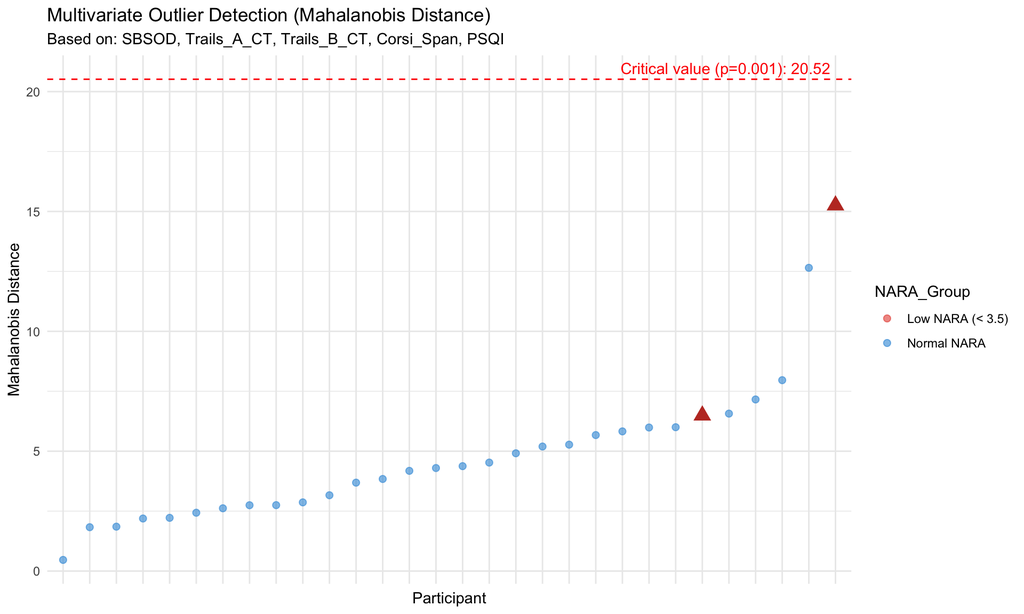

```r
# Calculate Mahalanobis distance
if (nrow(cog_metrics) > ncol(cog_metrics)) {
  mahal_dist <- mahalanobis(cog_metrics,
                             center = colMeans(cog_metrics),
                             cov = cov(cog_metrics))

  # Chi-square critical value (df = number of variables, p = 0.001)
  critical_value <- qchisq(0.999, df = ncol(cog_metrics))

  # Add Mahalanobis distance back to participant data
  measures_complete <- measures_complete %>%
    mutate(
      Mahalanobis_Distance = mahal_dist,
      Is_Multivariate_Outlier = mahal_dist > critical_value
    )

  # Show results for all participants
  mahal_results <- measures_complete %>%
    arrange(desc(Mahalanobis_Distance)) %>%
    mutate(Rank = row_number())

  kable(head(mahal_results, 10), digits = 2,
        caption = "Top 10 Multivariate Outliers (Mahalanobis Distance)")

  # Highlight BNC01 and BNC037
  low_nara_mahal <- mahal_results %>%
    filter(Participant %in% low_nara)

  kable(low_nara_mahal, digits = 2,
        caption = "Mahalanobis Distance for BNC01 and BNC037")

  # Visualize
  ggplot(mahal_results, aes(x = reorder(Participant, Mahalanobis_Distance),
                            y = Mahalanobis_Distance)) +
    geom_point(aes(color = NARA_Group), size = 2, alpha = 0.6) +
    geom_point(data = low_nara_mahal,
               aes(x = Participant, y = Mahalanobis_Distance),
               color = "#c0392b", size = 4, shape = 17) +
    geom_hline(yintercept = critical_value, color = "red", linetype = "dashed") +
    annotate("text", x = Inf, y = critical_value,
             label = paste0("Critical value (p=0.001): ", round(critical_value, 2)),
             hjust = 1.1, vjust = -0.5, color = "red") +
    scale_color_manual(values = colors) +
    labs(title = "Multivariate Outlier Detection (Mahalanobis Distance)",
         subtitle = paste("Based on:", paste(key_multivariate_measures, collapse = ", ")),
         x = "Participant", y = "Mahalanobis Distance") +
    theme_minimal() +
    theme(axis.text.x = element_blank(),
          axis.ticks.x = element_blank())
}
```

### Outlier Detection Summary

```r
# Combine all outlier detection results
outlier_summary <- measures_of_interest %>%
  select(Participant, NARA_Group, NARA) %>%
  left_join(
    iqr_outliers %>%
      filter(Is_Outlier) %>%
      count(Participant, name = "N_IQR_Outliers"),
    by = "Participant"
  ) %>%
  left_join(
    zscore_outliers %>%
      filter(Is_Outlier_2SD) %>%
      count(Participant, name = "N_ZScore_Outliers"),
    by = "Participant"
  ) %>%
  left_join(
    measures_complete %>%
      select(Participant, Mahalanobis_Distance, Is_Multivariate_Outlier),
    by = "Participant"
  ) %>%
  replace_na(list(N_IQR_Outliers = 0, N_ZScore_Outliers = 0,
                  Is_Multivariate_Outlier = FALSE)) %>%
  mutate(
    Total_Outlier_Flags = N_IQR_Outliers + N_ZScore_Outliers +
                          as.integer(Is_Multivariate_Outlier)
  ) %>%
  arrange(desc(Total_Outlier_Flags))

kable(head(outlier_summary, 10), digits = 2,
      caption = "Combined Outlier Detection Summary (Top 10)")
```

Combined Outlier Detection Summary (Top 10)

| Participant | NARA_Group | NARA | N_IQR_Outliers | N_ZScore_Outliers | Mahalanobis_Distance | Is_Multivariate_Outlier | Total_Outlier_Flags |
| --- | --- | --- | --- | --- | --- | --- | --- |
| BNC34 | Normal NARA | 6.0 | 4 | 5 | 12.65 | FALSE | 9 |
| BNC07 | Normal NARA | 5.5 | 4 | 1 | 5.27 | FALSE | 5 |
| BNC27 | Normal NARA | 7.0 | 2 | 2 | 4.30 | FALSE | 4 |
| BNC36 | Normal NARA | 4.5 | 1 | 3 | 7.96 | FALSE | 4 |
| NAV061 | Normal NARA | 4.5 | 3 | 1 | 3.69 | FALSE | 4 |
| BNC29 | Normal NARA | 4.5 | 1 | 2 | 3.16 | FALSE | 3 |
| BNC37 | Low NARA (< 3.5) | 1.5 | 2 | 1 | 15.26 | FALSE | 3 |
| BNC03 | Normal NARA | 6.0 | 1 | 1 | 2.22 | FALSE | 2 |
| BNC04 | Normal NARA | 6.5 | 1 | 1 | 4.38 | FALSE | 2 |
| BNC05 | Normal NARA | 7.5 | 0 | 1 | 2.87 | FALSE | 1 |

```r
# Highlight BNC01 and BNC037
low_nara_summary <- outlier_summary %>%
  filter(Participant %in% low_nara)

kable(low_nara_summary, digits = 2,
      caption = "Combined Outlier Summary for BNC01 and BNC037")
```

Combined Outlier Summary for BNC01 and BNC037

| Participant | NARA_Group | NARA | N_IQR_Outliers | N_ZScore_Outliers | Mahalanobis_Distance | Is_Multivariate_Outlier | Total_Outlier_Flags |
| --- | --- | --- | --- | --- | --- | --- | --- |
| BNC37 | Low NARA (< 3.5) | 1.5 | 2 | 1 | 15.26 | FALSE | 3 |
| BNC01 | Low NARA (< 3.5) | 3.0 | 0 | 0 | 6.49 | FALSE | 0 |

### Visualization: Outlier Status Across Metrics

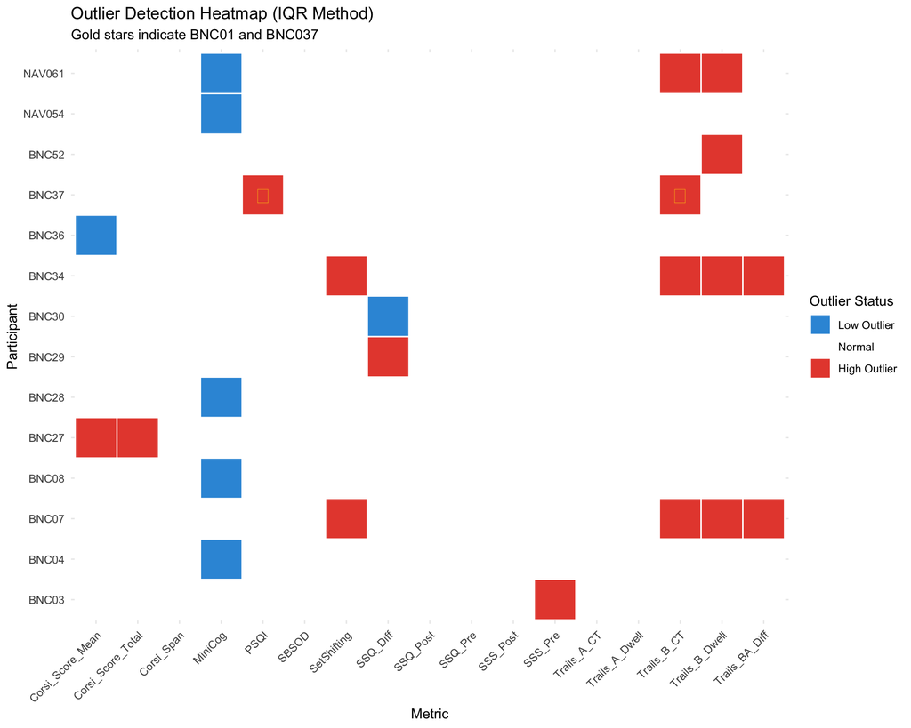

```r
# Create a heatmap of outlier status
outlier_heatmap_data <- iqr_outliers %>%
  select(Participant, Metric, Is_Outlier, Outlier_Type) %>%
  mutate(
    Outlier_Value = case_when(
      Outlier_Type == "High" ~ 1,
      Outlier_Type == "Low" ~ -1,
      TRUE ~ 0
    )
  )

# Focus on participants with any outliers
participants_with_outliers <- outlier_heatmap_data %>%
  filter(Is_Outlier) %>%
  pull(Participant) %>%
  unique()

if (length(participants_with_outliers) > 0) {
  ggplot(outlier_heatmap_data %>% filter(Participant %in% participants_with_outliers),
         aes(x = Metric, y = Participant, fill = factor(Outlier_Value))) +
    geom_tile(color = "white", linewidth = 0.5) +
    geom_text(data = outlier_heatmap_data %>%
                filter(Participant %in% low_nara, Is_Outlier),
              aes(label = "★"), size = 6, color = "gold") +
    scale_fill_manual(values = c("-1" = "#3498db", "0" = "white", "1" = "#e74c3c"),
                      labels = c("Low Outlier", "Normal", "High Outlier"),
                      name = "Outlier Status") +
    labs(title = "Outlier Detection Heatmap (IQR Method)",
         subtitle = "Gold stars indicate BNC01 and BNC037",
         x = "Metric", y = "Participant") +
    theme_minimal() +
    theme(axis.text.x = element_text(angle = 45, hjust = 1))
}
```

## Statistical Comparisons

```r
# T-tests comparing low NARA vs normal NARA
test_results <- data.frame()

for (measure in numeric_cols) {
  if (measure %in% colnames(measures_of_interest)) {
    test_data <- measures_of_interest %>%
      select(NARA_Group, !!measure) %>%
      na.omit()

    low_nara_vals <- test_data %>%
      filter(NARA_Group == "Low NARA (< 3.5)") %>%
      pull(measure)

    normal_nara_vals <- test_data %>%
      filter(NARA_Group == "Normal NARA") %>%
      pull(measure)

    if (length(low_nara_vals) > 0 && length(normal_nara_vals) > 1 &&
        sd(c(low_nara_vals, normal_nara_vals)) > 0) {

      t_test <- t.test(low_nara_vals, normal_nara_vals)

      test_results <- rbind(test_results, data.frame(
        Measure = measure,
        Low_NARA_Mean = mean(low_nara_vals, na.rm = TRUE),
        Normal_NARA_Mean = mean(normal_nara_vals, na.rm = TRUE),
        Difference = mean(low_nara_vals, na.rm = TRUE) - mean(normal_nara_vals, na.rm = TRUE),
        T_Statistic = t_test$statistic,
        P_Value = t_test$p.value,
        N_Low = length(low_nara_vals),
        N_Normal = length(normal_nara_vals)
      ))
    }
  }
}

test_results <- test_results %>%
  arrange(P_Value)

kable(test_results, digits = 3,
      caption = "Statistical Comparisons: Low NARA vs Normal NARA")
```

Statistical Comparisons: Low NARA vs Normal NARA

|  | Measure | Low_NARA_Mean | Normal_NARA_Mean | Difference | T_Statistic | P_Value | N_Low | N_Normal |
| --- | --- | --- | --- | --- | --- | --- | --- | --- |
| t15 | Corsi_Score_Mean | 4.750 | 5.639 | -0.889 | -4.605 | 0.024 | 2 | 28 |
| t7 | MiniCog | 5.000 | 4.786 | 0.214 | 2.274 | 0.031 | 2 | 28 |
| t14 | Corsi_Score_Total | 76.500 | 90.107 | -13.607 | -4.314 | 0.033 | 2 | 28 |
| t9 | Trails_A_Dwell | 8.900 | 10.932 | -2.032 | -1.924 | 0.202 | 2 | 28 |
| t5 | SSQ_Diff | 4.500 | 0.750 | 3.750 | 2.312 | 0.203 | 2 | 28 |
| t3 | SSQ_Pre | 3.500 | 2.464 | 1.036 | 1.554 | 0.215 | 2 | 28 |
| t4 | SSQ_Post | 8.000 | 3.214 | 4.786 | 2.235 | 0.218 | 2 | 28 |
| t1 | SSS_Pre | 1.500 | 2.036 | -0.536 | -0.993 | 0.465 | 2 | 28 |
| t | PSQI | 8.500 | 4.857 | 3.643 | 1.037 | 0.487 | 2 | 28 |
| t11 | Trails_B_Dwell | 14.950 | 18.368 | -3.418 | -0.772 | 0.565 | 2 | 28 |
| t8 | Trails_A_CT | 27.650 | 25.793 | 1.857 | 0.665 | 0.608 | 2 | 28 |
| t6 | SBSOD | 3.535 | 4.410 | -0.875 | -0.648 | 0.630 | 2 | 28 |
| t2 | SSS_Post | 2.500 | 1.786 | 0.714 | 0.472 | 0.717 | 2 | 28 |
| t16 | Corsi_Span | 6.500 | 6.679 | -0.179 | -0.343 | 0.783 | 2 | 28 |
| t10 | Trails_B_CT | 40.000 | 36.664 | 3.336 | 0.270 | 0.830 | 2 | 28 |
| t12 | Trails_BA_Diff | 12.350 | 10.871 | 1.479 | 0.099 | 0.937 | 2 | 28 |
| t13 | SetShifting | 12.350 | 10.871 | 1.479 | 0.099 | 0.937 | 2 | 28 |

## Percentile Rankings

```r
# Calculate percentile ranks for BNC01 and BNC037
percentile_data <- measures_of_interest %>%
  filter(Participant %in% low_nara) %>%
  select(Participant, all_of(numeric_cols)) %>%
  pivot_longer(-Participant, names_to = "Measure", values_to = "Value") %>%
  filter(!is.na(Value)) %>%
  left_join(
    measures_of_interest %>%
      select(Participant, all_of(numeric_cols)) %>%
      pivot_longer(-Participant, names_to = "Measure", values_to = "Value") %>%
      filter(!is.na(Value)) %>%
      group_by(Measure) %>%
      summarise(All_Values = list(Value)),
    by = "Measure"
  ) %>%
  rowwise() %>%
  mutate(
    Percentile = sum(Value >= unlist(All_Values)) / length(unlist(All_Values)) * 100
  ) %>%
  select(Participant, Measure, Value, Percentile) %>%
  arrange(Participant, Percentile)

kable(percentile_data, digits = 2,
      caption = "Percentile Rankings for BNC01 and BNC037")
```

Percentile Rankings for BNC01 and BNC037

| Participant | Measure | Value | Percentile |
| --- | --- | --- | --- |
| BNC01 | Trails_BA_Diff | -2.50 | 3.33 |
| BNC01 | SetShifting | -2.50 | 3.33 |
| BNC01 | SBSOD | 2.20 | 6.67 |
| BNC01 | Corsi_Score_Total | 74.00 | 6.67 |
| BNC01 | Corsi_Score_Mean | 4.60 | 6.67 |
| BNC01 | Trails_B_Dwell | 10.70 | 13.33 |
| BNC01 | Trails_B_CT | 27.80 | 16.67 |
| BNC01 | Corsi_Span | 6.00 | 43.33 |
| BNC01 | Trails_A_Dwell | 9.80 | 50.00 |
| BNC01 | PSQI | 5.00 | 66.67 |
| BNC01 | SSS_Pre | 2.00 | 76.67 |
| BNC01 | SSQ_Pre | 4.00 | 80.00 |
| BNC01 | Trails_A_CT | 30.30 | 80.00 |
| BNC01 | SSQ_Post | 10.00 | 93.33 |
| BNC01 | SSQ_Diff | 6.00 | 93.33 |
| BNC01 | SSS_Post | 4.00 | 100.00 |
| BNC01 | MiniCog | 5.00 | 100.00 |
| BNC37 | Corsi_Score_Total | 79.00 | 13.33 |
| BNC37 | Corsi_Score_Mean | 4.90 | 13.33 |
| BNC37 | Trails_A_Dwell | 8.00 | 16.67 |
| BNC37 | SSS_Pre | 1.00 | 33.33 |
| BNC37 | SSS_Post | 1.00 | 53.33 |
| BNC37 | Trails_A_CT | 25.00 | 56.67 |
| BNC37 | SBSOD | 4.87 | 63.33 |
| BNC37 | SSQ_Pre | 3.00 | 66.67 |
| BNC37 | SSQ_Post | 6.00 | 73.33 |
| BNC37 | Trails_B_Dwell | 19.20 | 76.67 |
| BNC37 | SSQ_Diff | 3.00 | 83.33 |
| BNC37 | Corsi_Span | 7.00 | 86.67 |
| BNC37 | Trails_B_CT | 52.20 | 93.33 |
| BNC37 | Trails_BA_Diff | 27.20 | 93.33 |
| BNC37 | SetShifting | 27.20 | 93.33 |
| BNC37 | PSQI | 12.00 | 100.00 |
| BNC37 | MiniCog | 5.00 | 100.00 |

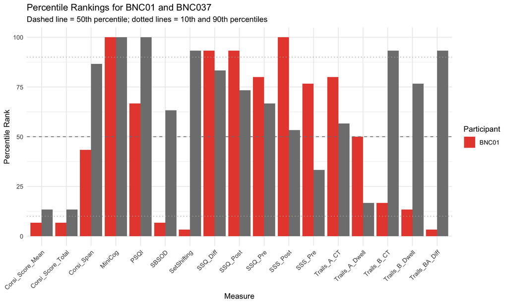

```r
# Visualize percentiles
ggplot(percentile_data, aes(x = Measure, y = Percentile, fill = Participant)) +
  geom_col(position = "dodge") +
  geom_hline(yintercept = 50, linetype = "dashed", color = "gray50") +
  geom_hline(yintercept = c(10, 90), linetype = "dotted", color = "gray70") +
  scale_fill_manual(values = c("BNC01" = "#e74c3c", "BNC037" = "#c0392b")) +
  labs(title = "Percentile Rankings for BNC01 and BNC037",
       subtitle = "Dashed line = 50th percentile; dotted lines = 10th and 90th percentiles",
       x = "Measure", y = "Percentile Rank") +
  theme_minimal() +
  theme(axis.text.x = element_text(angle = 45, hjust = 1))
```

## Conclusion

### Key Findings:

1. **NARA Scores**: BNC01 and BNC037 scored below the 3.5 cutoff on the NARA assessment
2. **Outlier Detection**:
   - **IQR Method**: Identifies measures where these participants fall outside Tukey’s fences
   - **Z-Score Method**: Flags measures more than 2 standard deviations from the mean
   - **Mahalanobis Distance**: Detects multivariate outliers across cognitive domains
   - The summary tables show total outlier flags across all methods
3. **Statistical Comparisons**: T-tests reveal whether the low NARA group differs significantly from normal NARA on each measure
4. **Percentile Rankings**: Show exactly where BNC01 and BNC037 fall in the YA distribution for each measure

### Interpretation:

- **Red triangles** identify BNC01 and BNC037 in scatter plots
- **Gold stars** in the heatmap indicate statistical outliers
- Measures where these participants are outliers may represent specific cognitive domains affected by low NARA performance
- **Percentile ranks below 10%** or **above 90%** suggest extreme performance on that measure
- The **Mahalanobis distance** reveals if they show unusual patterns across multiple cognitive domains

### Clinical Relevance:

Outlier status on cognitive/behavioral measures combined with low NARA scores could indicate: - Cognitive domains most affected in individuals with poor spatial memory - Whether low NARA represents a broader cognitive profile or specific deficit - Potential subtypes within the YA population worth investigating further